# Digits

Piotr Zawal

31 lipca 2019

#https://www.r-bloggers.com/exploring-handwritten-digit-classification-a-tidy-analysis-of-the-mnist-dataset/ Deep neural networks with ~99.8% accuracy #http://repository.supsi.ch/5145/1/IDSIA-04-12.pdf # https://www.kaggle.com/kobakhit/digital-recognizer-in-r !!!! #https://rrighart.github.io/Digits/ !!!! #https://www.kaggle.com/srlmayor/easy-neural-network-in-r-for-0-994 # http://varianceexplained.org/r/digit-eda/

# Wstęp

```r
# wczytaj dane
train <-  read.csv("./train.csv")
test <- read.csv("./test.csv")

# rozmiar zbioru treningowego i testowego
dim(test)
```

```
## [1] 28000   784
```

```r
dim(train)
```

```
## [1] 42000   785
```

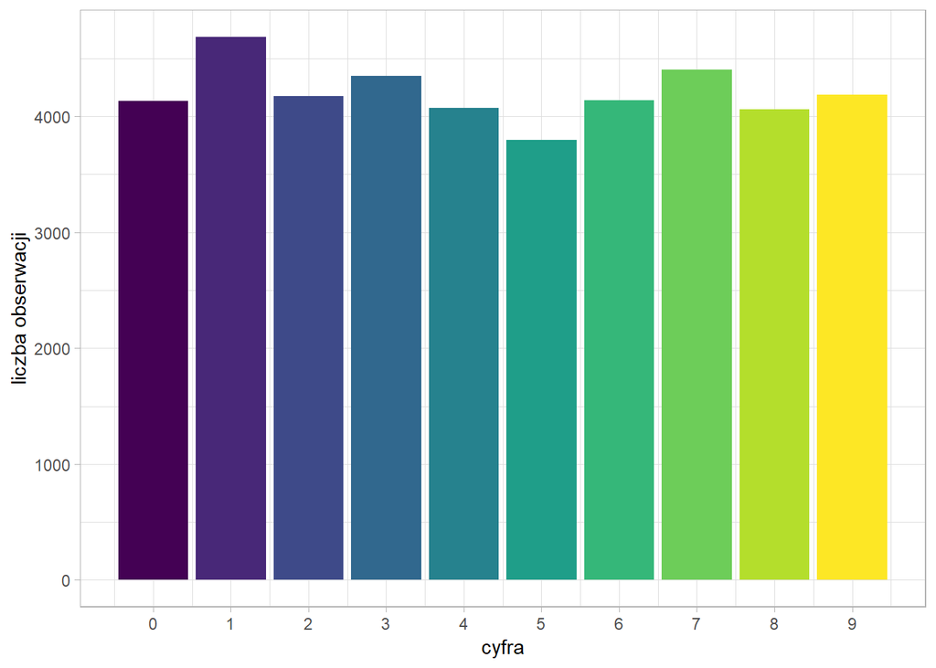

```r
# rozkład liczby obserwacji (cyfr) w zbiorze treningowym i testowym
ggplot(train, aes(x = label)) +
    geom_bar(fill = viridis(10)) +
    scale_x_continuous(breaks = 0:10) +
    xlab("cyfra") +
    ylab("liczba obserwacji")
```

```r
head(train)
```

[output not shown]

[output cut: 664 more lines]

# Analiza eksploracyjna

Wymiary macierzy: $\sqrt{784} = 28$, zatem wymiary obrazka to $28 \times 28$ pikseli. Tak wygląda losowo wybrana cyfra po transformacji z wektora do macierzy 28x28.

```r
matrix(train[15, -1], nrow = 28, ncol = 28, byrow = TRUE) %>%
    write.table(row.names = FALSE, col.names = FALSE, sep = "  ")
```

```
## 0  0  0  0  0  0  0  0  0  0  0  0  0  0  0  0  0  0  0  0  0  0  0  0  0  0  0  0
## 0  0  0  0  0  0  0  0  0  0  0  0  0  0  0  0  0  0  0  0  0  0  0  0  0  0  0  0
## 0  0  0  0  0  0  0  0  0  0  0  0  0  0  0  0  0  0  0  0  0  0  0  0  0  0  0  0
## 0  0  0  0  0  0  0  0  0  0  0  0  0  0  0  0  0  0  0  0  0  0  0  0  0  0  0  0
## 0  0  0  0  0  0  0  0  0  0  101  222  253  253  192  113  88  0  0  0  0  0  0  0  0  0  0  0
## 0  0  0  0  0  0  0  10  85  226  249  252  252  252  253  252  246  209  38  0  0  0  0  0  0  0  0  0
## 0  0  0  0  0  0  13  156  252  253  233  195  195  195  196  214  252  252  221  32  0  0  0  0  0  0  0  0
## 0  0  0  0  0  0  57  252  252  162  56  0  0  0  0  28  121  252  252  216  18  0  0  0  0  0  0  0
## 0  0  0  0  0  0  57  252  173  0  0  0  0  0  0  0  25  205  252  253  27  0  0  0  0  0  0  0
## 0  0  0  0  0  0  57  253  253  0  0  0  0  0  0  0  0  92  253  255  27  0  0  0  0  0  0  0
## 0  0  0  0  0  0  38  224  252  126  0  0  0  0  0  0  51  243  252  253  27  0  0  0  0  0  0  0
## 0  0  0  0  0  0  0  53  195  110  0  0  0  0  0  51  101  252  252  190  12  0  0  0  0  0  0  0
## 0  0  0  0  0  0  0  0  0  0  0  7  29  29  92  243  252  252  252  253  177  53  0  0  0  0  0  0
## 0  0  0  0  0  0  0  0  0  0  126  165  252  252  253  252  252  252  252  253  252  195  0  0  0  0  0  0
## 0  0  0  0  0  0  0  0  0  0  226  253  253  253  255  215  140  140  140  192  253  253  146  0  0  0  0  0
## 0  0  0  0  0  0  0  0  0  0  178  252  242  167  106  18  0  0  0  12  228  252  223  0  0  0  0  0
## 0  0  0  0  0  0  0  0  0  0  19  55  49  0  0  0  0  0  0  0  225  252  223  0  0  0  0  0
## 0  0  0  0  0  0  0  0  0  0  0  0  0  0  0  0  0  0  16  92  243  252  129  0  0  0  0  0
## 0  0  0  0  0  0  0  0  0  0  0  0  0  0  0  0  0  16  203  253  252  220  37  0  0  0  0  0
## 0  0  0  0  0  0  0  0  0  0  0  0  0  0  0  0  26  207  253  255  215  31  0  0  0  0  0  0
## 0  0  0  0  101  225  175  0  0  0  0  0  10  85  147  225  231  252  252  168  33  0  0  0  0  0  0  0
## 0  0  0  0  113  252  208  57  57  57  57  166  203  252  253  252  239  195  118  0  0  0  0  0  0  0  0  0
## 0  0  0  0  38  234  252  252  252  253  252  252  252  252  225  176  65  0  0  0  0  0  0  0  0  0  0  0
## 0  0  0  0  0  100  221  252  252  253  127  112  112  112  0  0  0  0  0  0  0  0  0  0  0  0  0  0
## 0  0  0  0  0  0  0  0  0  0  0  0  0  0  0  0  0  0  0  0  0  0  0  0  0  0  0  0
## 0  0  0  0  0  0  0  0  0  0  0  0  0  0  0  0  0  0  0  0  0  0  0  0  0  0  0  0
## 0  0  0  0  0  0  0  0  0  0  0  0  0  0  0  0  0  0  0  0  0  0  0  0  0  0  0  0
## 0  0  0  0  0  0  0  0  0  0  0  0  0  0  0  0  0  0  0  0  0  0  0  0  0  0  0  0
```

W celu wykonania lepszej jakości obrazów przekształcimy dane do postaci dwuwymiarowej.

```r
train_2dim <- train %>%
                head(1000) %>%
                # dodaj dodatkowy rząd z numerem wiersza
                mutate(instance = row_number()) %>%
                # zmień format tabeli (wide data -> long data)
                gather(pixel, value, -label, -instance) %>%
                # ekstrakcja numeru piksela z kolumny "pixel" za pomocą wyrażeń regularnych
                tidyr::extract(pixel, "pixel", "(\\d+)", convert = TRUE) %>%
                # dodaj kolumnę z koordynatami piksela
                mutate(x = pixel %% 28,
                       y = 28 - pixel %/% 28)
```

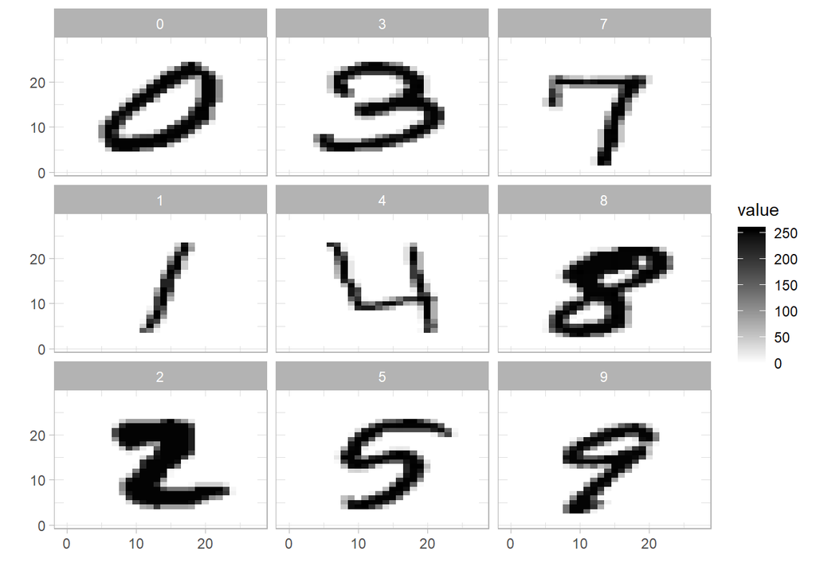

```r
train_2dim %>%
    filter(instance <= 18) %>%
    ggplot(aes(x, y, fill = value)) +
    geom_tile() +
    facet_wrap(facets = ~ label,
               dir = "v") +
    scale_fill_gradient(low = "white", high = "black") +
    xlab("") +
    ylab("")
```

Obrazowanie danych w postaci dwuwymiarowej będzie wykorzystywane kilkukrotnie podczas analizy zbioru, dlatego zdefiniowano funkcję `{r}printDigits()`. Argumentami funkcji jest cyfra, która będzie wykreślona (digit) oraz liczba paneli (domyślna wartość argumentu numOfDigits to 16).

```r
printDigits <- function(digit, numOfDigits = 16) {
    if (!require("gridExtra")) install.packages("gridExtra")

    plots <- list()

    for (i in 1:numOfDigits) {

        digits_data <- train[train$label == digit, ] %>% sample_n(1)

        plots [[i]] <- digits_data %>%
            gather() %>%
            filter( key != "label") %>%
            mutate(row = row_number() - 1) %>%
            mutate(col = row %% 28, row = row %/% 28) %>%
            ggplot() +
            geom_tile(aes(col, 28 - row, fill = value), show.legend = FALSE) +
            scale_fill_gradient(low = "white", high = "black") +
            coord_equal() +
            theme_void() +
            theme(plot.background = element_rect(fill = "gray80"))
    }

do.call("grid.arrange", c(plots, ncol = 4, nrow = ceiling(numOfDigits / 4)))
}
```

```r
#train[train$label == 7, ][i, ]
```

```r
printDigits <- function(dataset, digit, numOfDigits = 16, plotRandom = TRUE) {
    if (!require("gridExtra")) install.packages("gridExtra")

    plots <- list()

    for (i in 1:numOfDigits) {

        if (plotRandom) {
            digits_data <- dataset[dataset$label == digit, ] %>% sample_n(1)
        } else {

            digits_data <- dataset[dataset$label == digit, ][i, ]
        }


        plots [[i]] <- digits_data %>%
            gather() %>%
            filter( key != "label") %>%
            mutate(row = row_number() - 1) %>%
            mutate(col = row %% 28, row = row %/% 28) %>%
            ggplot() +
            geom_tile(aes(col, 28 - row, fill = value), show.legend = FALSE) +
            scale_fill_gradient(low = "white", high = "black") +
            coord_equal() +
            theme_void() +
            theme(plot.background = element_rect(fill = "gray80"))
    }

do.call("grid.arrange", c(plots, ncol = 4, nrow = ceiling(numOfDigits / 4)))
}
```

```r
#train[train$label == digit, ] %>% sample_n(1)
```

Z pomocą tej funkcji łatwo będzie można wykreślić losowo wybrane cyfry, np:

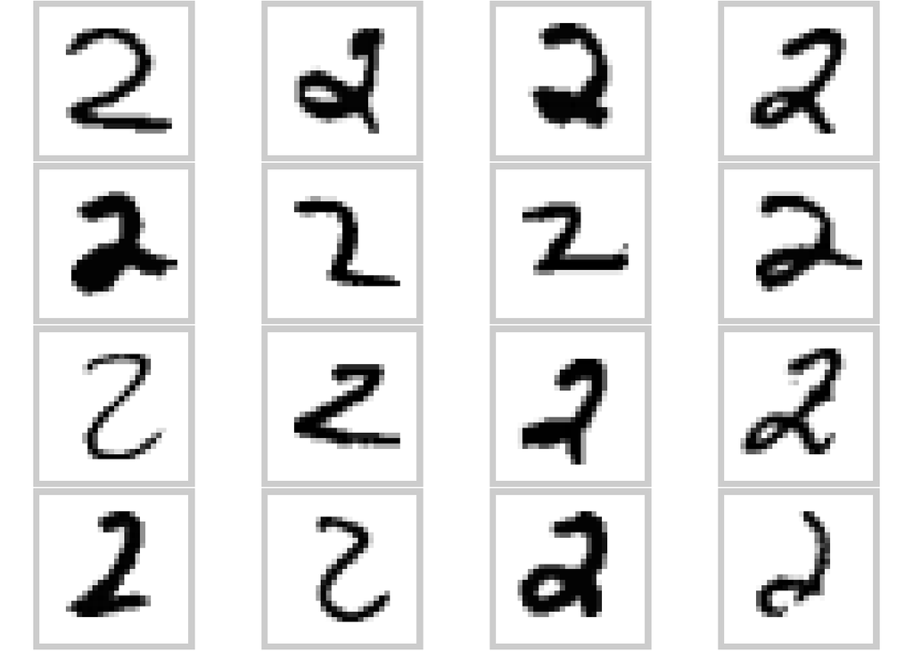

```r
printDigits(train, 2)
```

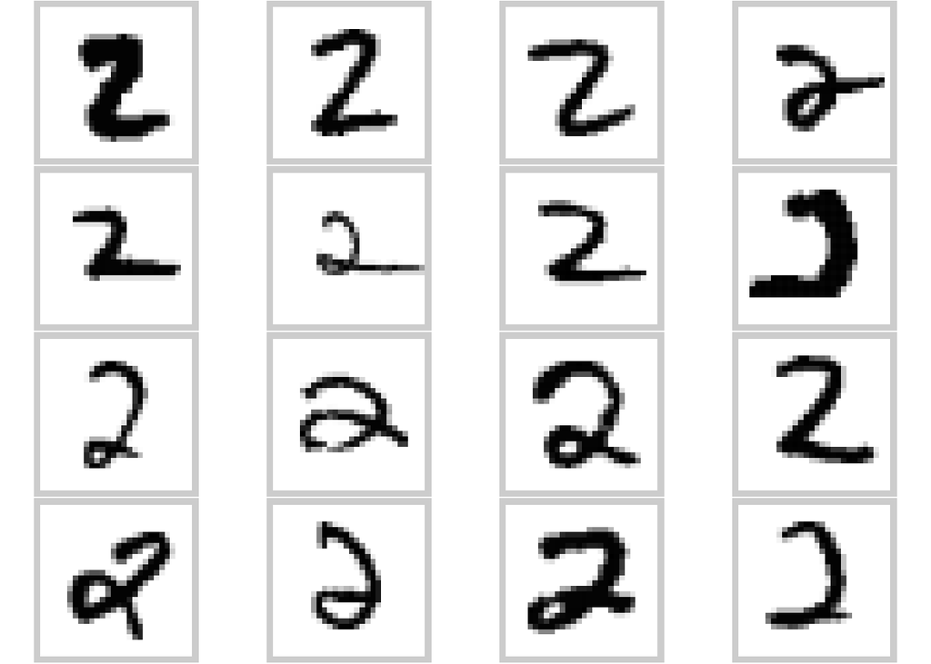

```r
printDigits(train, 2, plotRandom = FALSE)
```

Data exploration

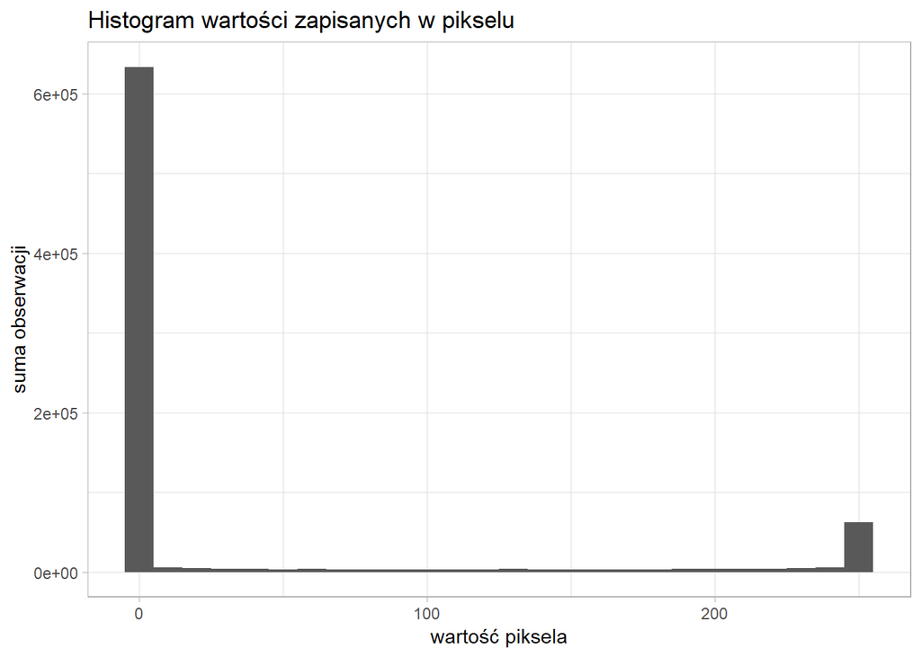

```r
ggplot(train_2dim, aes(value)) +
    geom_histogram(binwidth = 10) +
    xlab("wartość piksela") +
    ylab("suma obserwacji") +
    ggtitle("Histogram wartości zapisanych w pikselu")
```

Histogram z wyłączeniem - wynika z niego, że dominującą wartością jest 255 (kolor czarny), cyfry powinny mieć więc dobrze zdefiniowane kontury.

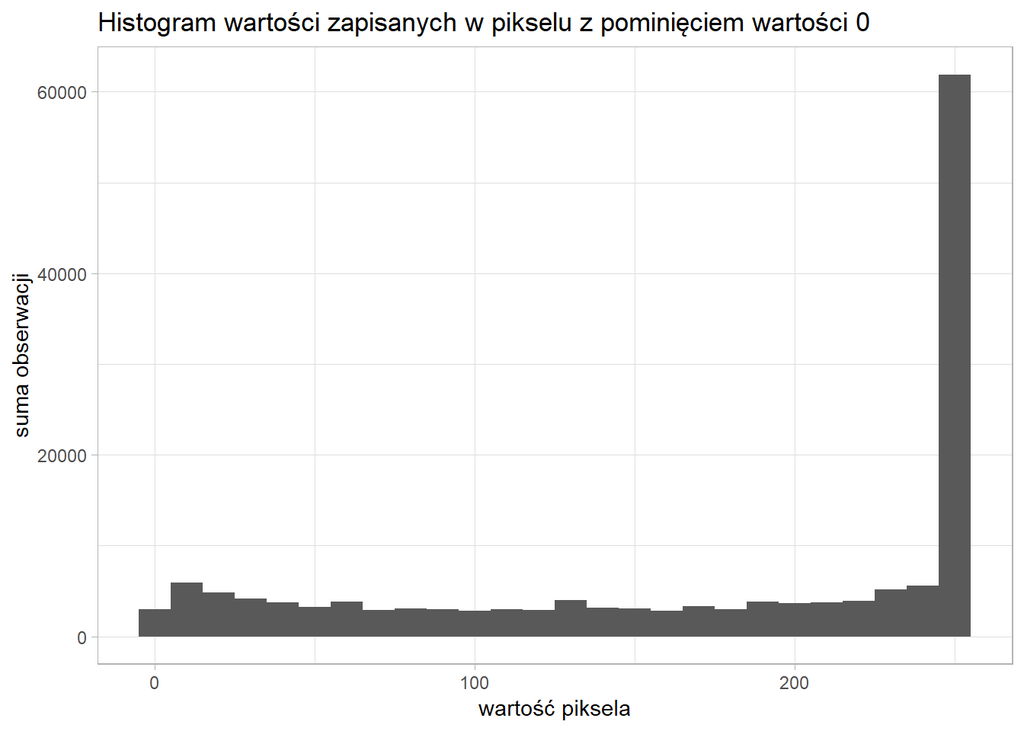

```r
train_2dim %>%
    filter(value != 0) %>%
    ggplot(aes(value)) +
    geom_histogram(binwidth = 10) +
    xlab("wartość piksela") +
    ylab("suma obserwacji") +
    ggtitle("Histogram wartości zapisanych w pikselu z pominięciem wartości 0")
```

Liczymy jak wygląda “średnia” cyfra:

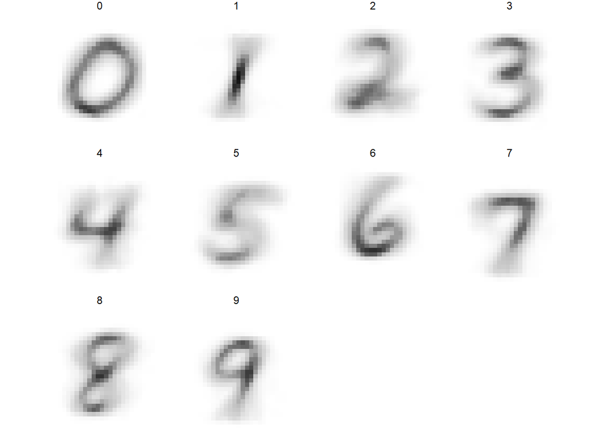

```r
# oblicz jak wygląda uśredniona cyfra
average_digit <- train_2dim %>%
    group_by(x, y, label) %>%
    summarize(mean_pixel_value = mean(value)) %>%
    ungroup()

# average_digit

average_digit %>%
    ggplot(aes(x, y, fill = mean_pixel_value)) +
        geom_tile(show.legend = FALSE) +
        facet_wrap(facets = ~ label) +
        scale_fill_gradient2(low = "white",
                             high = "black",
                             mid = "gray",
                             midpoint = 127.5) +
        xlab("") +
        ylab("") +
        coord_equal() +
        theme_void()
```

Wszystkie uśrednione cyfry są czytelne i mogą bez trudu być rozróżnione przez człowieka. W zbiorze na pewno znajdują się jednak cyfry, których kształt odbiega od uśrednionego kształtu. Aby ocenić skalę zjawiska sprawdzono, w której klasie jest największa wariancja. Jako miarę różnicy pomiędzy średnią i wybraną obserwacją, wybrano średnią odległość euklidesową dla każdej cyfry:
$$d_{Euklides}=\sqrt{\frac{\sum{}_{i=1}^n(\hat{y}_i - y_i)^2}{n}}$$
gdzie: $y_i$ to wartość i-tego piksela, $\hat{y}_i$ to wartość piksela uśredniona po wszystkich obserwacjach w danej klasie a $n$ to liczba wszystkich obserwacji.

```r
digits_joined <- inner_join(train_2dim, average_digit, by = c("label", "x", "y"))

digit_distances <- digits_joined %>%
    group_by(label, instance) %>%
    summarize(euclidean_distance = sqrt(mean((value - mean_pixel_value) ^ 2)))

digit_distances %>%
    arrange(desc(euclidean_distance)) %>%
    head(20)
```

```
## # A tibble: 20 x 3
## # Groups:   label [7]
##    label instance euclidean_distance
##    <int>    <int>              <dbl>
##  1     9      500               91.2
##  2     7      680               89.8
##  3     5      444               89.0
##  4     8      682               86.0
##  5     6      180               85.3
##  6     5       20               85.1
##  7     6      923               84.8
##  8     8       68               83.8
##  9     3      241               83.2
## 10     7      133               82.3
## 11     8      177               82.3
## 12     3      904               82.2
## 13     6      757               81.6
## 14     8      863               81.4
## 15     3      716               81.2
## 16     6      991               81.1
## 17     1      898               80.8
## 18     8      198               80.6
## 19     6      501               80.3
## 20     5      916               80.2
```

W dwudziestu pierwszych obserwacjach odległość euklidesowa ma wartość wyższą niż 80.

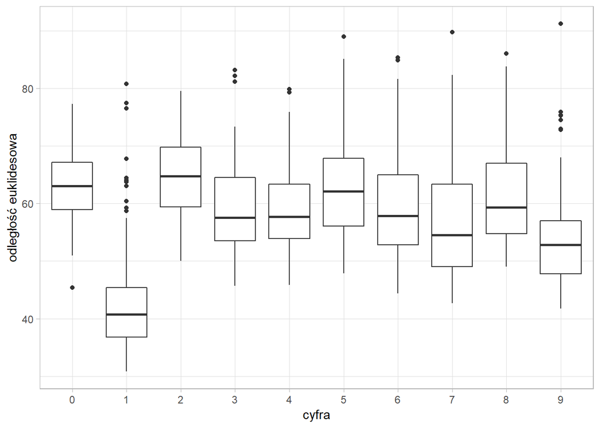

```r
ggplot(digit_distances, aes(x = factor(label), y = euclidean_distance)) +
    geom_boxplot() +
    xlab("cyfra") +
    ylab("odległość euklidesowa")
```

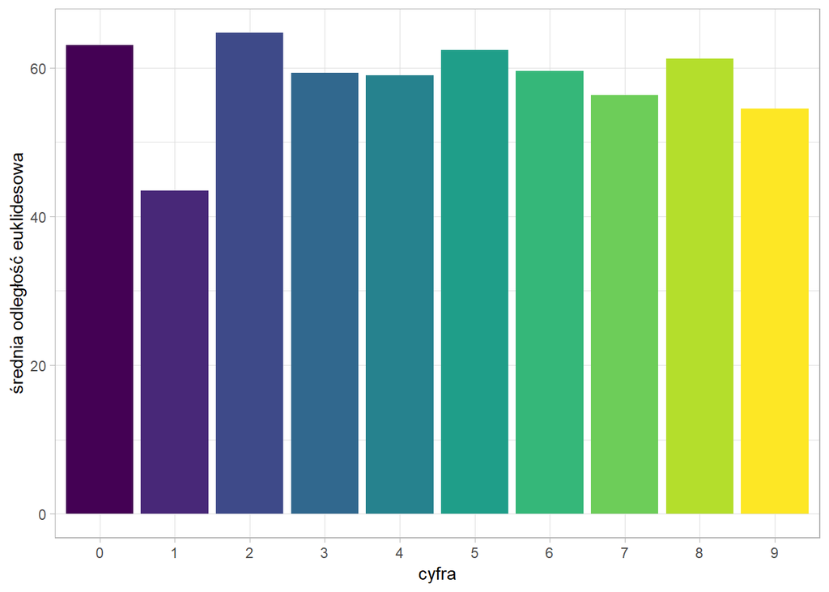

```r
digit_distances %>%
    group_by(label) %>%
    summarise(mean_distance = mean(euclidean_distance)) %>%
    ggplot(aes(x = as.factor(label), y = mean_distance)) +
    geom_bar(stat = "identity", fill = viridis(10)) +
    ylab("średnia odległość euklidesowa") +
    xlab("cyfra")
```

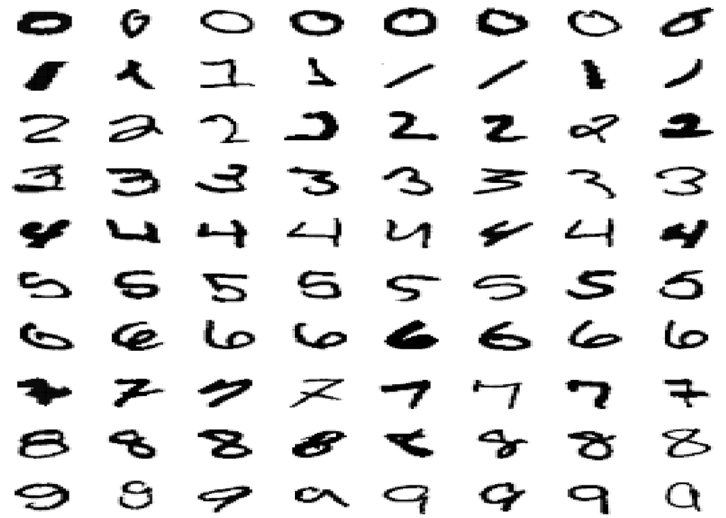

```r
highest_distances <- as.tbl(digit_distances) %>%
    # dla każdej klasy wybierz 8 obserwacji z największymi odległościami euklidesowymi
    top_n(euclidean_distance, n = 8) %>%
    # dodaj kolumnę szeregującą obserwacje wg. odległości euklidesowej
    mutate(number = rank(-euclidean_distance))


inner_join(train_2dim, highest_distances, by = c("label", "instance")) %>%
    ggplot(aes(x, y, fill = value)) +
    geom_tile(show.legend = FALSE) +
    scale_fill_gradient2(low = "white",
                        high = "black",
                        mid = "gray",
                        midpoint = 127.5) +
    facet_grid(label ~ number) +
    theme_void() +
    theme(strip.text = element_blank())
```

# Przygotowanie danych do modelowania

# https://www.youtube.com/watch?v=5bso_5X7Zu4

```r
train_y <- train$label
train_y <- as.factor(train_y)
train_x <- train[, -1]

dim(test)
```

```
## [1] 28000   784
```

```r
dim(train_x)
```

```
## [1] 42000   784
```

```r
# standaryzowanie danych
train_x <- ceiling(train_x / 255)
test_x <- ceiling(test / 255)
```

W celu łatwiejszej wizualizacji ustandaryzowanych danych posłużono się zmienną `{r} train_2dim`, wobec której zastosowano taką samą technikę standaryzacji wartości pikseli.

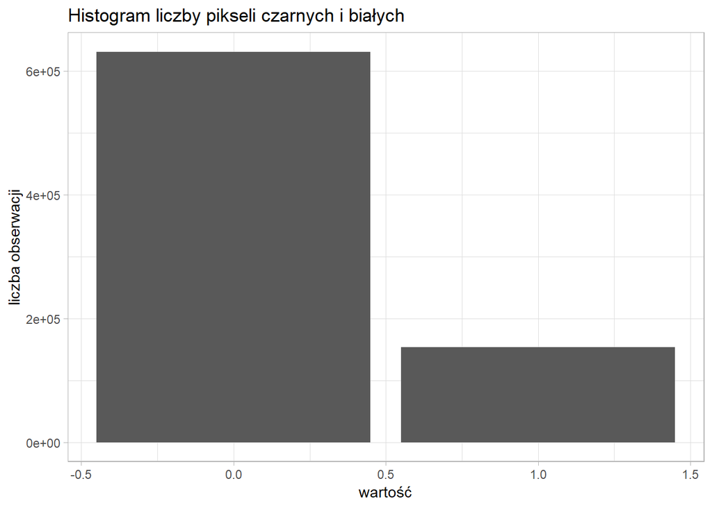

```r
ggplot(train_2dim, aes(ceiling(value / 255))) +
    geom_bar() +
    xlab("wartość") +
    ylab("liczba obserwacji") +
    ggtitle("Histogram liczby pikseli czarnych i białych")
```

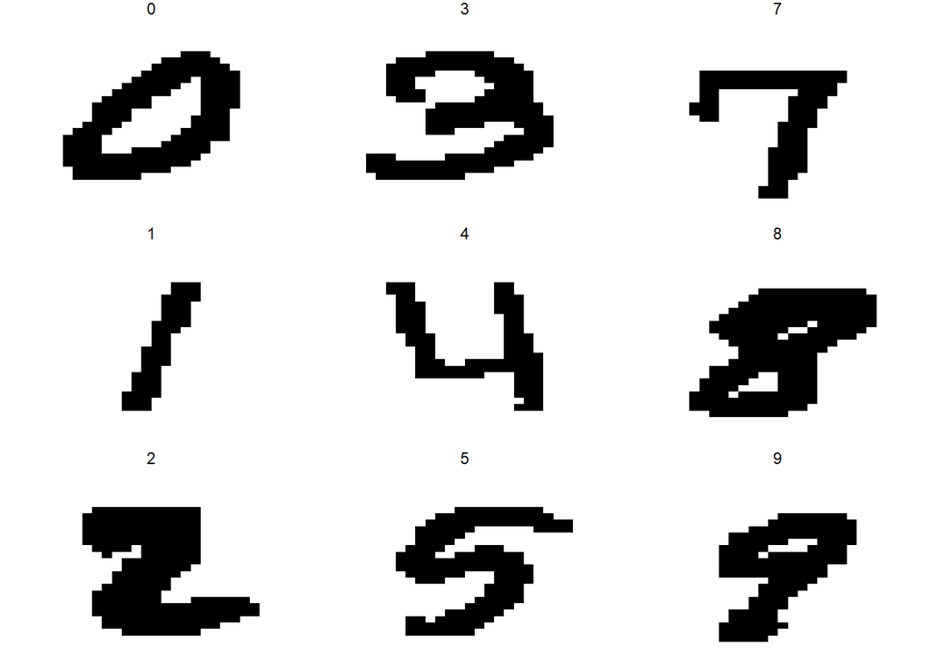

```r
train_2dim %>%
    filter(instance <= 18) %>%
    ggplot(aes(x, y, fill = ceiling(value / 255))) +
    geom_tile(show.legend = FALSE) +
    facet_wrap(facets = ~ label,
               dir = "v") +
    scale_fill_gradient(low = "white", high = "black") +
    xlab("") +
    ylab("") +
    theme_void()
```

```r
# wczytaj bibliotekę do głębokich sieci neuronowych
library(keras)

# przygotowanie zbioru treningowego i testowego
train_images <- train[, -1]
train_labels <- train$label

test_images <- test

train_images <- train_images / 255

test_images <- test_images / 255
```

Keras, jako danych wejściowych, wymaga macierzy. Obecny typ danych to lista:

```r
typeof(train_images)
```

```
## [1] "list"
```

```r
typeof(test_images)
```

```
## [1] "list"
```

Zbiory przekształcono w typ macierzy:

```r
# keras wymaga macierzy jako typu danych wejściowych
train_images <- as.matrix(train_images)
test_image <- as.matrix(test_images)
```

```r
train_labels <- to_categorical(train_labels)
str(train_labels)
```

```
##  num [1:42000, 1:10] 0 1 0 0 1 1 0 0 0 0 ...
```

```r
head(train_labels, 10)
```

```
##       [,1] [,2] [,3] [,4] [,5] [,6] [,7] [,8] [,9] [,10]
##  [1,]    0    1    0    0    0    0    0    0    0     0
##  [2,]    1    0    0    0    0    0    0    0    0     0
##  [3,]    0    1    0    0    0    0    0    0    0     0
##  [4,]    0    0    0    0    1    0    0    0    0     0
##  [5,]    1    0    0    0    0    0    0    0    0     0
##  [6,]    1    0    0    0    0    0    0    0    0     0
##  [7,]    0    0    0    0    0    0    0    1    0     0
##  [8,]    0    0    0    1    0    0    0    0    0     0
##  [9,]    0    0    0    0    0    1    0    0    0     0
## [10,]    0    0    0    1    0    0    0    0    0     0
```

Definicja modelu:

```r
# keras - model 1
network <- keras_model_sequential() %>%
  layer_dense(units = 512, activation = "relu", input_shape = c(784)) %>%
  layer_dense(units = 10, activation = "softmax")

# keras - model 2
network2 <- keras_model_sequential() %>%
  layer_dense(units = 512, activation = "relu", input_shape = c(784)) %>%
  layer_dense(units = 10, activation = "softmax")
```

```r
# kompilacja modelu
network %>% compile(
  optimizer = "rmsprop",
  # categorical_crossentropy measures the distance between two probability distributions
  loss = "categorical_crossentropy",
  metrics = c("accuracy")
)
# zapisz początkowe wagi modelu
save_model_weights_hdf5(network, "./network.h5")

network2 %>% compile(
  optimizer = "rmsprop",
  # categorical_crossentropy measures the distance between two probability distributions
  loss = "categorical_crossentropy",
  metrics = c("accuracy")
)
save_model_weights_hdf5(network2, "./network2.h5")
```

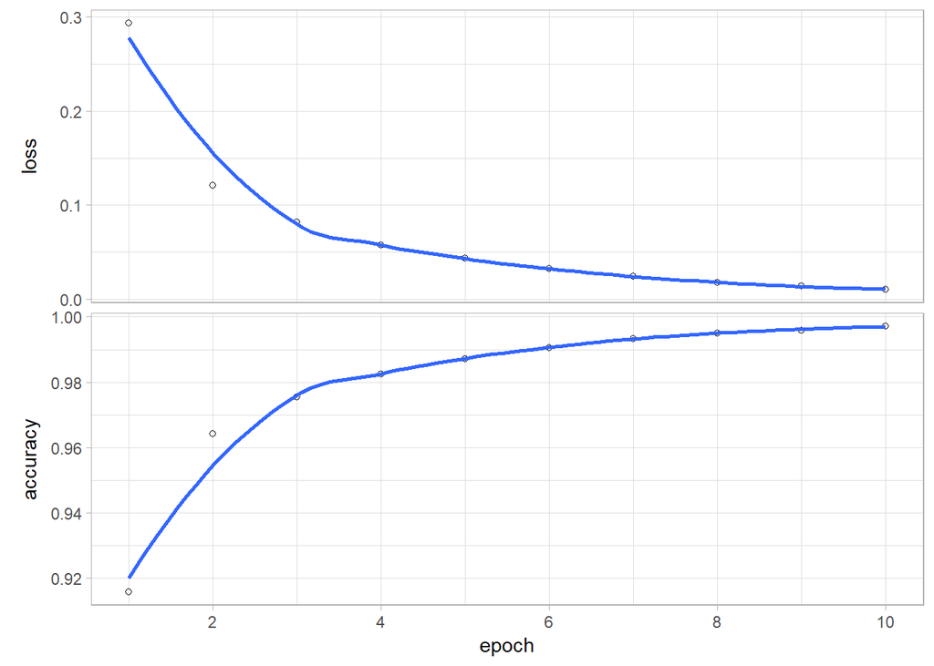

```r
#str(train_images)
#str(train_labels)
model_1 <- network %>% fit(train_images, train_labels, epochs = 10, batch_size = 128)
plot(model_1)
```

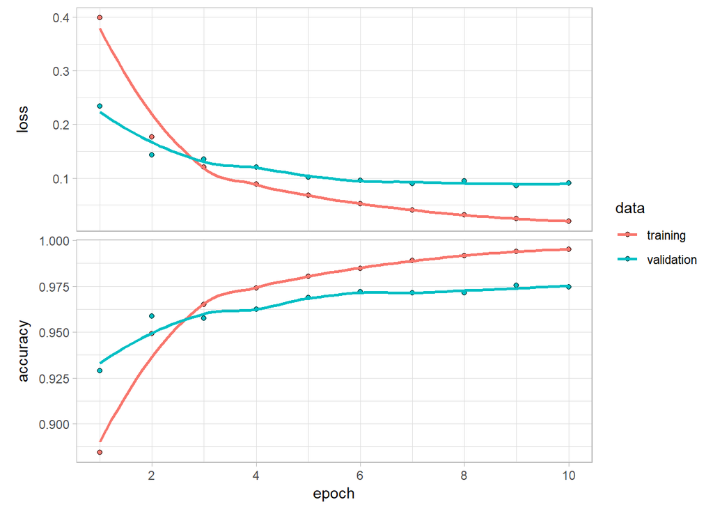

```r
load_model_weights_hdf5(network2, "./network.h5")
model_2_epoch_10 <- network2 %>% fit(train_images, train_labels, epochs = 10, batch_size = 256, validation_split = 0.2)
plot(model_2_epoch_10)
```

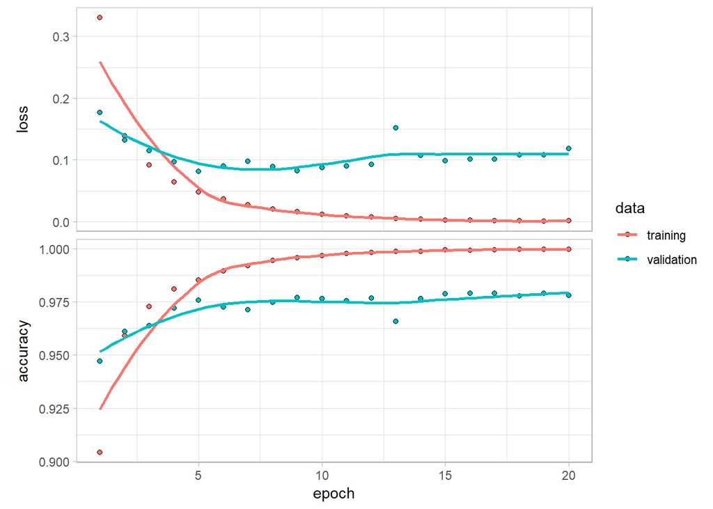

```r
load_model_weights_hdf5(network2, "./network.h5")
model_2_epoch_20 <- network2 %>% fit(train_images, train_labels, epochs = 20, batch_size = 128, validation_split = 0.2)
plot(model_2_epoch_20)
```

```r
# # wyślij predictions
# predictions <- network2 %>% predict_classes(as.matrix(test_images))
# head(predictions)
# submit_predictions <-  read.csv("./sample_submission.csv")
# submit_predictions$Label <- predictions
# head(submit_predictions)
# write.csv(submit_predictions, "./sample_submission_keras.csv", row.names = FALSE)
#
# head(cbind(submit_predictions$ImageId, predictions))
```

```r
# # data_frame z prawdziwą i przewidzianą klasą
# model_1
# model_2
# pred_class <- predict_classes(network,
#                               train,
#                               batch_size = 32,
#                               verbose = 1)
#
# train_df <- tibble(train_images = apply(train_images, 1, which.max) - 1, pred_class)
# table(train_df)
```

# https://www.kaggle.com/timokerremans/cnn-for-minst-dataset

```r
# train_df %>%
#     count(train_images, pred_class) %>%
#     ungroup() %>%
#     filter(train_images != pred_class) %>%
#     ggplot() +
#         geom_tile(aes(as.factor(train_images), as.factor(pred_class), fill = n))
```